# Iris dataset

### Homegrown linear regression

We want to solve for `x` in

```
Ax = b,
```

where `A` is our data matrix (rows are samples) and `b` is the variable we're trying to predict. However, `A` is generally not invertible. `A^T A`, however, IS invertible, as long as the columns of `A` are linearly independent. So we instead solve for `xhat` in

```
A^T A xhat = A^T b,
xhat = (A^T A)^-1 A^T b,
```

and this minimises the error because `A xhat` is the projection of `b` onto the column space of `A`, i.e. `xhat` gets us as close to `b` as possible given `A`.

```python
A = iris.drop(["species", "petal_width"], axis=1).to_numpy()
b = iris["petal_width"].to_numpy()
```

```python
proj = np.matmul(np.linalg.inv(np.matmul(A.T, A)), A.T)
```

```python
xhat = np.dot(proj, b)
```

```python
xhat
```

```
array([-0.25010419,  0.20945778,  0.53804957])
```

```python
bhat = np.dot(A, xhat)
```

```python
err = (b-bhat)
print("Mean squared error:", np.dot(err, err)/len(b))
```

```
Mean squared error: 0.03631971456742261
```

```python
model = linear_model.LinearRegression()
model.fit(A, b)
```

```
LinearRegression()
```

```python
sk_bhat = model.predict(A)
sk_err = (b-sk_bhat)
print("sklearn mean squared error:", np.dot(sk_err, sk_err)/len(b))
```

```
sklearn mean squared error: 0.03584110914511173
```

I'm not sure how the sklearn version is able to get slightly lower error! Maybe it adds a column of all-1s to allow a constant term?

### Gaussian discriminative analysis (GDA)

This is a generative classification algorithm. Rather than directly predicting the probability `P(y|x)` for a class `y` and data `x`, it instead models the data in each class using a Gaussian distribution, giving `P(x|y)`. Then, using the prior probabilities `P(y)` and Bayes' Rule, this gives...

```
P(y0|x) = P(x,y)/P(x)
        = P(y0)P(x|y0) / (sum_{y} P(y)P(x|y)).
```

Let's see how it compares to logistic regression. Assuming a Gaussian distribution might not be a bad idea, given that phenotypes traits in animals tend to be normally distributed due to being the result of many different effects (genes).

Also worth noting that GDA can be reduced to logistic regression, but not vice versa.

```python
class GDA:
    def fit(self, X, y):
        self.classes, counts = np.unique(y, return_counts=True)
        N = len(y)
        self.P_y = counts / N
        self.means = []
        for i, c in enumerate(self.classes):
            mask = y == c
            self.means.append(np.sum(X[mask], axis=0)/np.sum(mask))
        A = X - np.mean(X, axis=0)
        # We share the covariance matrix across all the classes.
        self.cov = np.matmul(A.T, A)/N

    def predict(self, X, return_prob=False):
        P_x_and_y = []
        for mean, P_y in zip(self.means, self.P_y):
            P_x_and_y.append(P_y * multivariate_normal.pdf(X, mean=mean, cov=self.cov))
        P_y_given_x = np.stack(P_x_and_y).T
        P_y_given_x /= np.sum(P_y_given_x, axis=1)[:,np.newaxis]
        if return_prob:
            return P_y_given_x
        return np.array([self.classes[np.argmax(probs)]
                        for probs in P_y_given_x])
```

```python
iris.species = pd.Categorical(iris.species)

X = iris.drop(["species"], axis=1).to_numpy()
y = pd.Categorical(iris.species).codes

test_pct = 0.35
X_train, X_test, y_train, y_test = train_test_split(X, y, test_size=test_pct, random_state=42)
```

```python
model = GDA()
model.fit(X_train, y_train)
```

Take a look at the model parameters. A reminder that the features are: sepal_length, sepal_width, petal_length, petal_width.

```python
print(model.means)
print(model.P_y)
print(model.cov)
```

```
[array([4.96451613, 3.36129032, 1.46774194, 0.24516129]), array([5.86363636, 2.71212121, 4.21212121, 1.3030303 ]), array([6.52121212, 2.96969697, 5.51212121, 2.00909091])]
[0.31958763 0.34020619 0.34020619]
[[ 0.6785567  -0.01742268  1.22969072  0.49030928]
 [-0.01742268  0.17654586 -0.26200128 -0.09271761]
 [ 1.22969072 -0.26200128  2.9838155   1.24197258]
 [ 0.49030928 -0.09271761  1.24197258  0.56296312]]
```

```python
pred_test = model.predict(X_test)
pred_test
```

```
array([1, 0, 2, 1, 1, 0, 1, 2, 1, 1, 2, 0, 0, 0, 0, 2, 2, 1, 1, 2, 0, 2,
       0, 2, 2, 2, 1, 2, 0, 0, 0, 0, 2, 0, 0, 1, 2, 0, 0, 0, 2, 2, 2, 0,
       0, 1, 1, 2, 1, 2, 1, 2, 2], dtype=int8)
```

```python
print("{}% accuracy".format(round(100*np.sum(pred_test==y_test)/len(y_test), 3)))
```

```
83.019% accuracy
```

```
<sklearn.metrics._plot.confusion_matrix.ConfusionMatrixDisplay at 0x7f01bf5ecda0>
```

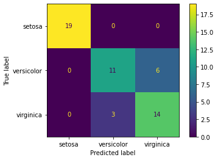

```python
cm = confusion_matrix(y_test, pred_test)
ConfusionMatrixDisplay(confusion_matrix=cm,
                       display_labels=["setosa", "versicolor", "virginica"]) \
    .plot()
```